# HollisT_Week5

Tim Hollis

2025-10-12

# Probability Theory: Modeling Uncertainty

Probability theory is the mathematical framework for quantifying uncertainty. It allows us to model random events, calculate expected outcomes, and simulate systems where chance plays a role. It helps us understand not what will happen, but what tends to happen over many trials.

Key concepts include:

- **Sample Space**: The set of all possible outcomes.
- **Random Variables**: Variables whose values depend on chance.
- **Probability Distributions**: Functions that assign likelihoods to outcomes.
- **Expected Value**: The long-run average outcome, weighted by probabilities.

### **License Plate Combinations**

We need to calculate how many different license plates can be made from six digits. Since each position can be any digit from 0-9, and positions are independent, we use the multiplication principle of counting.

```r
license_plate_combinations <- 10^6
format_number(license_plate_combinations)
```

```
## [1] "1,000,000"
```

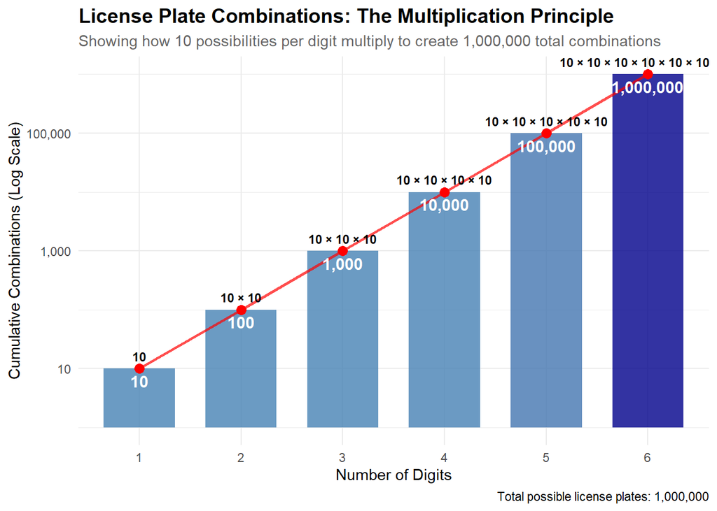

```r
# Create data that shows cumulative multiplication
combo_data <- data.frame(
  digits = 1:6,
  combinations = cumprod(rep(10, 6))
)

# Add labels for each step
combo_data$calculation <- c(
  '10',
  '10 × 10',
  '10 × 10 × 10',
  '10 × 10 × 10 × 10',
  '10 × 10 × 10 × 10 × 10',
  '10 × 10 × 10 × 10 × 10 × 10        '
)

ggplot(combo_data, aes(x = factor(digits), y = combinations)) +
  geom_col(aes(fill = combinations), width = 0.7, alpha = 0.8) +
  geom_point(aes(y = combinations), color = 'red', size = 3) +
  geom_line(aes(x = digits, y = combinations), group = 1,
            color = 'red', linewidth = 1, alpha = 0.7) +
  geom_text(aes(label = calculation),
            vjust = -0.8, size = 3, fontface = 'bold') +
  geom_text(aes(label = scales::comma(combinations)),
            vjust = 1.5, size = 4, fontface = 'bold', color = 'white') +
  scale_fill_gradient(low = 'steelblue', high = 'darkblue',
                      labels = scales::comma) +
  scale_y_log10(labels = scales::comma) +  # Log scale to better show growth
  labs(title = 'License Plate Combinations: The Multiplication Principle',
       subtitle = 'Showing how 10 possibilities per digit multiply to create 1,000,000 total combinations',
       x = 'Number of Digits',
       y = 'Cumulative Combinations (Log Scale)',
       caption = paste('Total possible license plates:', scales::comma(license_plate_combinations))) +
  theme(legend.position = 'none',
        plot.title = element_text(face = 'bold', size = 14),
        plot.subtitle = element_text(color = 'gray40'))
```

#### **Summary**

There are 10 possible digits for each of the 6 positions, so the total number of unique license plates is: **10⁶ = 1,000,000**

### **Probability of Getting ‘Heads’ Three Times in a Row**

We calculate the probability of three consecutive heads in coin flips. Each flip is independent with P(Heads) = 0.5, so we multiply probabilities.

```r
prob_heads_3 <- 0.5^3
format_number(prob_heads_3)
```

```
## [1] "0.125"
```

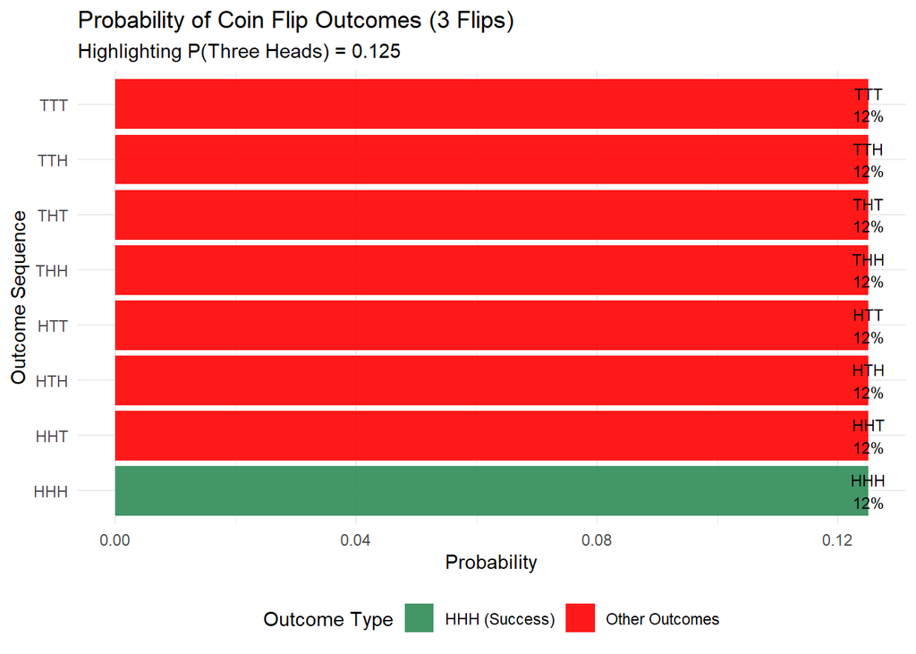

```r
# Generate all possible outcomes for 3 coin flips
coin_flips <- expand.grid(
  flip1 = c('H', 'T'),
  flip2 = c('H', 'T'),
  flip3 = c('H', 'T')
) %>%
  mutate(
    outcome = paste0(flip1, flip2, flip3),
    three_heads = ifelse(outcome == 'HHH', 'HHH (Success)', 'Other Outcomes'),
    probability = 1/8
  )

# Create visualization
ggplot(coin_flips, aes(x = reorder(outcome, probability), y = probability, fill = three_heads)) +
  geom_col(alpha = 0.9) +
  geom_text(aes(label = paste0(outcome, '\n', percent(probability))),
            position = position_stack(vjust = 0.5), size = 3) +
  scale_fill_manual(values = c('HHH (Success)' = '#2E8B57', 'Other Outcomes' = 'red')) +
  coord_flip() +
  labs(title = 'Probability of Coin Flip Outcomes (3 Flips)',
       subtitle = 'Highlighting P(Three Heads) = 0.125',
       x = 'Outcome Sequence',
       y = 'Probability',
       fill = 'Outcome Type') +
  theme(legend.position = 'bottom')
```

### **Probability of Drawing Ace of Spades then Two of Hearts**

We determine the probability of drawing a specific card out of the deck, followed by another specific card.

```r
prob_cards <- (1/52)*(1/51)
format_number(prob_cards)
```

```
## [1] "0.0003770739"
```

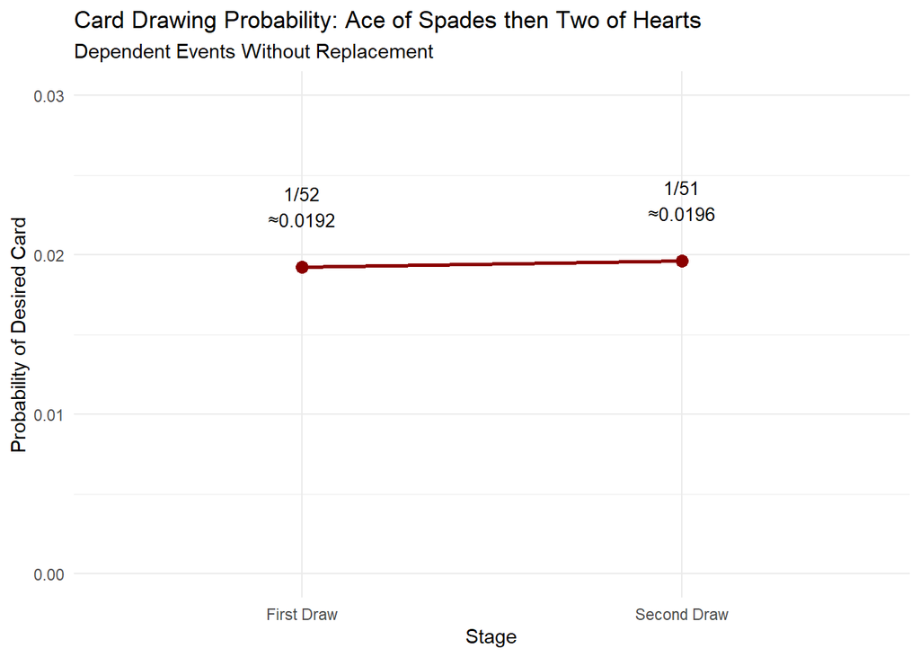

```r
# Create visualization of the probability tree
card_stages <- data.frame(
  Stage = factor(c('First Draw', 'Second Draw'), levels = c('First Draw', 'Second Draw')),
  Cards_Remaining = c(52, 51),
  Probability = c(1/52, 1/51)
)

ggplot(card_stages, aes(x = Stage, y = Probability, group = 1)) +
  geom_line(color = 'darkred', size = 1) +
  geom_point(size = 3, color = 'darkred') +
  geom_text(aes(label = paste0('1/', Cards_Remaining, '\n≈', round(Probability, 4))),
            vjust = -1, size = 3.5) +
  labs(title = 'Card Drawing Probability: Ace of Spades then Two of Hearts',
       subtitle = 'Dependent Events Without Replacement',
       y = 'Probability of Desired Card') +
  ylim(0, 0.03)
```

#### **Summary**

The probability of drawing the Ace of Spades followed by the Two of Hearts is:

**(1/52) × (1/51) ≈ 0.000377**

This is a compound probability with no replacement. After drawing one card, only 51 remain, which is why the probability of getting the second card is slightly higher. The multiplication rule applies because both events are dependent.

### **Conditional Dice Probability**

Given the first die shows 6, we find the probability that the sum equals 9. This is conditional probability where we only consider outcomes where the first die is 6.

```r
prob_sum_9_given_6 <- 1/6
format_number(prob_sum_9_given_6)
```

```
## [1] "0.1666667"
```

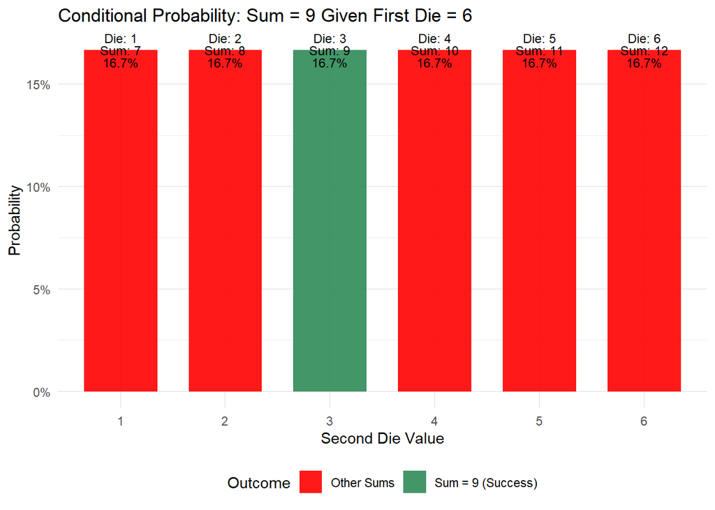

```r
# Create corrected dice outcomes table
dice_outcomes <- data.frame(
  second_die = 1:6,
  sum = 6 + 1:6,
  probability = rep(1/6, 6),
  is_target = ifelse(1:6 == 3, 'Sum = 9 (Success)', 'Other Sums')
)

ggplot(dice_outcomes, aes(x = factor(second_die), y = probability, fill = is_target)) +
  geom_col(width = 0.7, alpha = 0.9) +
  geom_text(aes(label = paste0('Die: ', second_die, '\nSum: ', sum, '\n', round(probability * 100, 1), '%')),
            position = position_stack(vjust = 0.5), size = 3.2, lineheight = 0.8) +
  scale_fill_manual(values = c('Sum = 9 (Success)' = '#2E8B57', 'Other Sums' = 'red')) +
  scale_y_continuous(labels = percent_format()) +
  labs(title = 'Conditional Probability: Sum = 9 Given First Die = 6',
       x = 'Second Die Value',
       y = 'Probability',
       fill = 'Outcome') +
  theme(legend.position = 'bottom')
```

#### **Summary**

Given the first die shows a 6, the probability that the total equals 9 is: **1/6 ≈ 0.1667, or 16.67%**

Only one value (3) on the second die will result in a total of 9. Since all outcomes are equally likely, the conditional probability is 1 out of 6.

### **EV: Investment Decision**

```r
ev_investment <- (0.3 * 70000) + (0.7*-40000)
format_number(ev_investment)
```

```
## [1] "-7,000"
```

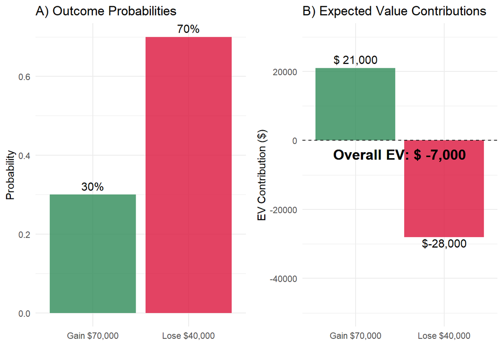

```r
investment_data <- data.frame(
  scenario = c('Gain $70,000', 'Lose $40,000'),
  probability = c(0.3, 0.7),
  value = c(70000, -40000),
  ev_contribution = c(0.3 * 70000, 0.7 * -40000)
)

# Create comprehensive EV visualization
p1 <- ggplot(investment_data, aes(x = scenario, y = probability, fill = value > 0)) +
  geom_col(alpha = 0.8) +
  geom_text(aes(label = percent(probability)), vjust = -0.5, size = 4) +
  scale_fill_manual(values = c('TRUE' = '#2E8B57', 'FALSE' = '#DC143C')) +
  labs(title = 'A) Outcome Probabilities',
       x = '', y = 'Probability') +
  theme(legend.position = 'none')

p2 <- ggplot(investment_data, aes(x = scenario, y = ev_contribution, fill = value > 0)) +
  geom_col(alpha = 0.8) +
  geom_hline(yintercept = 0, linetype = 'dashed', color = 'black') +
  geom_text(aes(label = paste0('$', format_number(ev_contribution))),
            vjust = ifelse(investment_data$ev_contribution > 0, -0.5, 1.2),
            size = 4) +
  geom_text(x = 1.5, y = ev_investment,
            label = paste('Overall EV: $', format_number(ev_investment)),
            vjust = -0.5, size = 5, color = 'black', fontface = 'bold') +
  scale_fill_manual(values = c('TRUE' = '#2E8B57', 'FALSE' = '#DC143C')) +
  labs(title = 'B) Expected Value Contributions',
       x = '', y = 'EV Contribution ($)') +
  theme(legend.position = 'none') +
  ylim(c(-50000, 30000))

grid.arrange(p1, p2, ncol = 2)
```

#### **Summary**

Because the result of adding a 70% chance of losing $40,000 and 30% chance of gaining $70,000, comes out to a -$7,000, which as the graphic shows, is comprised of multiplying 70k by .3 and adding that to the value obtained when multiplying -40k by .7 (which results in a negative number), this would not be a wise investment based solely on EV analysis.

### **EV: Lottery Ticket**

Lottery EV considers all possible prizes weighted by their probabilities, minus the ticket cost. Most lotteries have negative EV, making them poor financial investments

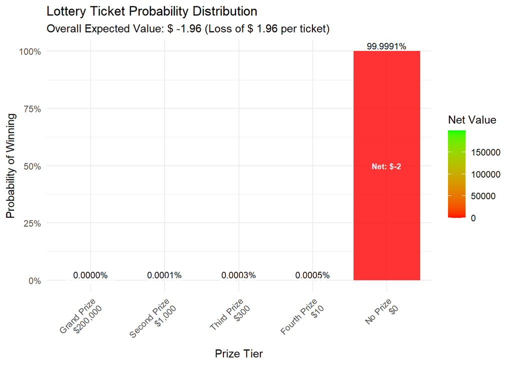

```r
total_tickets <- 5000000

# Calculate lottery probabilities and values
lottery_data <- data.frame(
  prize_tier = c('Grand Prize\n$200,000', 'Second Prize\n$1,000',
                 'Third Prize\n$300', 'Fourth Prize\n$10', 'No Prize\n$0'),
  num_winners = c(1, 5, 15, 25, total_tickets - 46),
  prize_value = c(200000, 1000, 300, 10, 0),
  net_value = c(200000-2, 1000-2, 300-2, 10-2, -2)  # Subtracting cost of ticket
)

# Calculate probabilities and EV contributions
lottery_data$probability <- lottery_data$num_winners / total_tickets
lottery_data$ev_contribution <- lottery_data$probability * lottery_data$net_value
ev_lottery <- sum(lottery_data$ev_contribution)

# Create a more informative visualization
ggplot(lottery_data, aes(x = reorder(prize_tier, probability),
                         y = probability,
                         fill = net_value)) +
  geom_col(alpha = 0.8) +
  geom_text(aes(label = scales::percent(probability, accuracy = 0.0001)),
            vjust = -0.3, size = 3) +
  geom_text(aes(label = paste0('Net: $', net_value),
                y = probability/2),
            size = 2.8, color = 'white', fontface = 'bold') +
  scale_fill_gradient2(low = 'red', mid = 'red', high = 'green',
                       midpoint = 0, name = 'Net Value') +
  scale_y_continuous(labels = scales::percent) +
  labs(title = 'Lottery Ticket Probability Distribution',
       subtitle = paste('Overall Expected Value: $', round(ev_lottery, 2),
                       '(Loss of $', round(abs(ev_lottery), 2), 'per ticket)'),
       x = 'Prize Tier',
       y = 'Probability of Winning') +
  theme(axis.text.x = element_text(angle = 45, hjust = 1))
```

#### **Summary**

With an expected value of -$1.96, purchasing this lottery ticket represents a poor financial decision. The negative value is comprised of the cost of the ticket, as more than 99.99% of entries will win $0, though you cant lose more than the total cost of ticket.

## Reflection for Week 5

### Things That Were Easily Completed or Made Sense

- **Markdown explanation of probability theory**: Writing the intro in Markdown felt familiar and helped set the tone for the assignment. It was a good way to anchor the logic before diving into calculations.
- **License plate permutations**: Calculating the number of possible six-digit combinations using basic multiplication was straightforward and reinforced foundational probability concepts.
- **Expected value for investment scenario**: Applying weighted outcomes to calculate expected value made sense conceptually, and the math translated well in R
- **Coin flip visualization**: Using ggplot2 to visualize the probability of three heads in a row was a fun way to connect theory to output. The GitHub examples helped scaffold the structure

### Things That Were Difficult or Required Extra Thought

- **Deck of cards probability**: Accounting for dependent events (drawing two specific cards in sequence without replacement) required careful attention to conditional probability and order of operations.
- **Dice problem with known outcome**: Interpreting the constraint “first die shows a 6” and narrowing the sample space to calculate conditional probability took extra effort to model correctly.
- **Expected value of the lottery**: Translating prize tiers and ticket volume into a weighted average required multiple steps and careful attention to units (e.g., subtracting ticket cost, scaling probabilities).
- **Function chaining and readability**: Keeping R code readable while chaining multiple operations (e.g., mutate(), summarize(), filter()) was trickier than expected, especially when debugging.

### Things I Will Continue or Stop Doing Moving Forward:

#### Continue:

- **Using comments and Markdown for clarity**: Annotating each step helped me stay organized and made the logic easier to follow when reviewing.
- **Breaking problems into smaller parts**: Tackling complex probability questions by isolating each event or outcome made the code more manageable.
- **Visualizing where possible**: Graphs and plots helped reinforce understanding and made abstract concepts more tangible.

#### Stop:

- **Relying on intuition for probability**: I’ll be more cautious about assuming outcomes without calculating them — especially in multi-step or conditional scenarios.
- **Skipping edge cases in code**: I’ll build in checks for zero probabilities, missing values, or unexpected inputs to make my code more robust.
- **Overcomplicating syntax**: I’ll aim for cleaner, more modular code instead of nesting too many operations in one line.